# Hypothesis Test

In-Class Activity

Last rendered on Thursday, November 04, 2021 @ 12:27 PM

### Packages Used

```r
library(tidyverse)
library(moderndive)
library(infer)
```

From *Modern Dive*, [Chapter 9](https://moderndive.com/9-hypothesis-testing.html)

Say you are working at a bank in the 1970s and you are submitting your résumé to apply for a promotion. Will your gender affect your chances of getting promoted? To answer this question, we’ll focus on data from a study published in the *Journal of Applied Psychology* in 1974. This data is also used in the OpenIntro series of statistics textbooks.

To begin the study, 48 bank supervisors were asked to assume the role of a hypothetical director of a bank with multiple branches. Every one of the bank supervisors was given a résumé and asked whether or not the candidate on the résumé was fit to be promoted to a new position in one of their branches.

However, each of these 48 résumés were identical in all respects except one: the name of the applicant at the top of the résumé. Of the supervisors, 24 were randomly given résumés with stereotypically “male” names, while 24 of the supervisors were randomly given résumés with stereotypically “female” names. Since only (binary) gender varied from résumé to résumé, researchers could isolate the effect of this variable in promotion rates.

While many people today (including us, the authors) disagree with such binary views of gender, it is important to remember that this study was conducted at a time where more nuanced views of gender were not as prevalent. Despite this imperfection, we decided to still use this example as we feel it presents ideas still relevant today about how we could study discrimination in the workplace.

The `moderndive` package contains the data on the 48 applicants in the `promotions` data frame.

### Promotions Dataset

```r
str(promotions)
```

```
tibble [48 × 3] (S3: tbl_df/tbl/data.frame)
 $ id      : int [1:48] 1 2 3 4 5 6 7 8 9 10 ...
 $ decision: Factor w/ 2 levels "not","promoted": 2 2 2 2 2 2 2 2 2 2 ...
 $ gender  : Factor w/ 2 levels "male","female": 1 1 1 1 1 1 1 1 1 1 ...
```

```r
head(promotions, 48)
```

```
# A tibble: 48 × 3
      id decision gender
   <int> <fct>    <fct>
 1     1 promoted male
 2     2 promoted male
 3     3 promoted male
 4     4 promoted male
 5     5 promoted male
 6     6 promoted male
 7     7 promoted male
 8     8 promoted male
 9     9 promoted male
10    10 promoted male
# … with 38 more rows
```

```r
promotions %>%
  group_by(gender, decision) %>%
  tally()
```

```
# A tibble: 4 × 3
# Groups:   gender [2]
  gender decision     n
  <fct>  <fct>    <int>
1 male   not          3
2 male   promoted    21
3 female not         10
4 female promoted    14
```

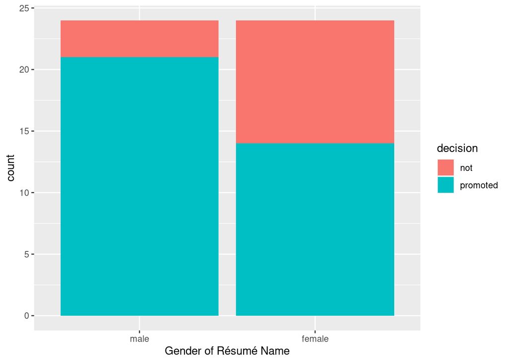

```r
ggplot(promotions,
       aes(x = gender, fill = decision)) +
  geom_bar() +
  labs(x = "Gender of Résumé Name")
```

### Shuffled Promotions Dataset

IF randomness is the only thing driving the difference … then what we’re seeing in the data is a random permutation of the system. So, what would other random permutations of the system look like?

First, how many people were promoted versus not promoted, regardless of gender?

```r
promotions %>%
  count(decision)
```

```
# A tibble: 2 × 2
  decision     n
  <fct>    <int>
1 not         13
2 promoted    35
```

Overall, 35 people were promoted, so we’ll keep that number. However, we’re going to randomly assign genders to the “promoted” and “not promoted” people. If gender does not matter and promotion is based solely on qualifications, then gender assignment is arbitrary anyway.

```r
str(promotions_shuffled)
```

```
tibble [48 × 3] (S3: tbl_df/tbl/data.frame)
 $ id      : int [1:48] 1 2 3 4 5 6 7 8 9 10 ...
 $ decision: Factor w/ 2 levels "not","promoted": 2 2 2 2 2 2 2 2 2 2 ...
 $ gender  : Factor w/ 2 levels "male","female": 2 2 1 2 1 1 1 2 1 2 ...
```

```r
head(promotions, 48)
```

```
# A tibble: 48 × 3
      id decision gender
   <int> <fct>    <fct>
 1     1 promoted male
 2     2 promoted male
 3     3 promoted male
 4     4 promoted male
 5     5 promoted male
 6     6 promoted male
 7     7 promoted male
 8     8 promoted male
 9     9 promoted male
10    10 promoted male
# … with 38 more rows
```

```r
head(promotions_shuffled, 48)
```

```
# A tibble: 48 × 3
      id decision gender
   <int> <fct>    <fct>
 1     1 promoted female
 2     2 promoted female
 3     3 promoted male
 4     4 promoted female
 5     5 promoted male
 6     6 promoted male
 7     7 promoted male
 8     8 promoted female
 9     9 promoted male
10    10 promoted female
# … with 38 more rows
```

```r
promotions_shuffled %>%
  group_by(gender, decision) %>%
  tally()
```

```
# A tibble: 4 × 3
# Groups:   gender [2]
  gender decision     n
  <fct>  <fct>    <int>
1 male   not          6
2 male   promoted    18
3 female not          7
4 female promoted    17
```

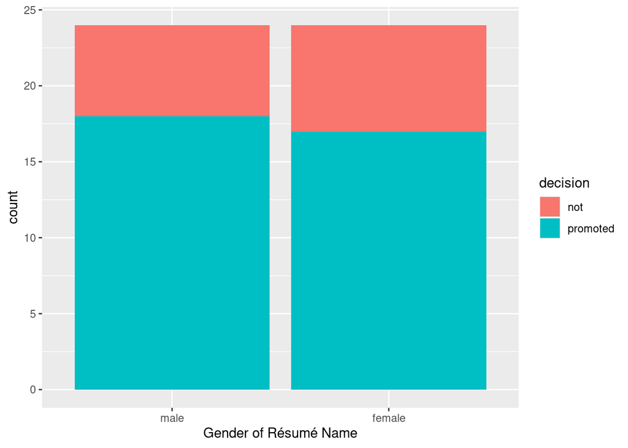

```r
ggplot(promotions_shuffled,
       aes(x = gender, fill = decision)) +
  geom_bar() +
  labs(x = "Gender of Résumé Name")
```

### Another Shuffled Promotions Dataset

We really need to look at more than one random shuffle, because we know by now that randomness can produce a variety of results, some of them rather extreme.

```r
promotions_shuffled_new <- promotions %>%
  mutate(gender = sample(gender)) # shuffles the gender column

promotions_shuffled_new %>%
  group_by(gender, decision) %>%
  tally()
```

```
# A tibble: 4 × 3
# Groups:   gender [2]
  gender decision     n
  <fct>  <fct>    <int>
1 male   not          8
2 male   promoted    16
3 female not          5
4 female promoted    19
```

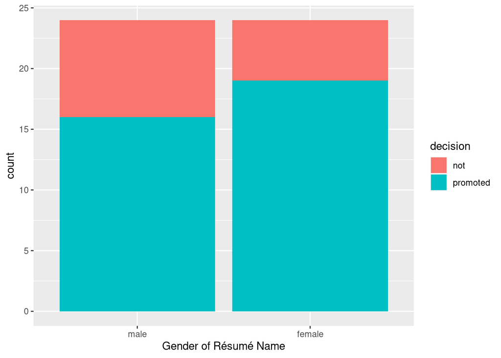

```r
ggplot(promotions_shuffled_new,
       aes(x = gender, fill = decision)) +
  geom_bar() +
  labs(x = "Gender of Résumé Name")
```

If we look at a bunch of random shufflings, we can see some cases where the proportions are similar, and some where they are quite different (like our data). How does our data fit into this big picture?

### Hypothesis Testing

#### Null and Alternative Hypotheses

In words: men and women are equally likely to be promoted. We measure that by looking at the proportions of men and women who were promoted. Those proportions are likelihoods or probabilities.

$p_{male}$ = population promotion of males who are promoted

$P_{female}$ = population proportion of females who are promoted

$$H_0: p_{male} = p_{female} \rightarrow p_{male} - p_{female} = 0$$

OR…are men more likely to be promoted (promoted at a greater rate)?

$$H_a: p_{male} > p_{female} \rightarrow p_{male} - p_{female} > 0$$

#### Test Statistic

We will estimate the difference in the hypotheses using our sample data.

$$\text{observed difference} = \hat{p}_{male} - \hat{p}_{female}$$

The *observed difference* is the difference in the data. It’s a point estimate of the difference in the population. We also call this the *test statistic*.

```r
obs_diff_prop <- promotions %>%
  specify(decision ~ gender, success = "promoted") %>%          # variable of interest ~ grouping variable
  calculate(stat = "diff in props", order = c("male", "female"))
obs_diff_prop
```

```
Response: decision (factor)
Explanatory: gender (factor)
# A tibble: 1 × 1
   stat
  <dbl>
1 0.292
```

#### Generate the Null Distribution

We will generate a bunch of random shuffles and compare our data to them.

```r
null_distribution <- promotions %>%
  specify(formula = decision ~ gender, success = "promoted") %>%
  hypothesize(null = "independence") %>%
  generate(reps = 1000, type = "permute") %>%
  calculate(stat = "diff in props", order = c("male", "female"))
```

What is the distribution of the statistic we’re looking at when Ho is true?

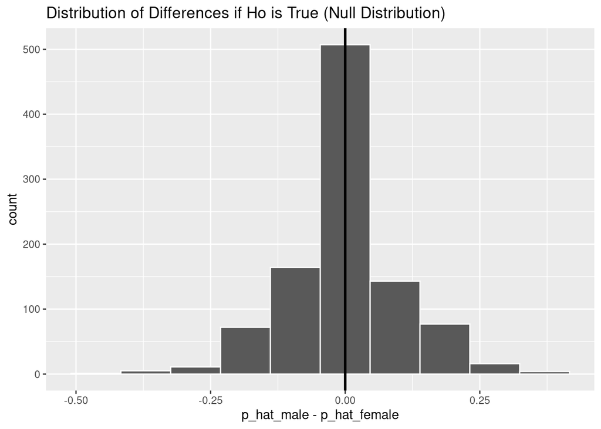

```r
visualize(null_distribution, bins = 10) +
  labs(title = "Distribution of Differences if Ho is True (Null Distribution)",
       x = "p_hat_male - p_hat_female") +
  geom_vline(xintercept = 0, size = 1)  # this represents the difference expected under Ho
```

#### Assess the Significance

Consider the alternative hypothesis.

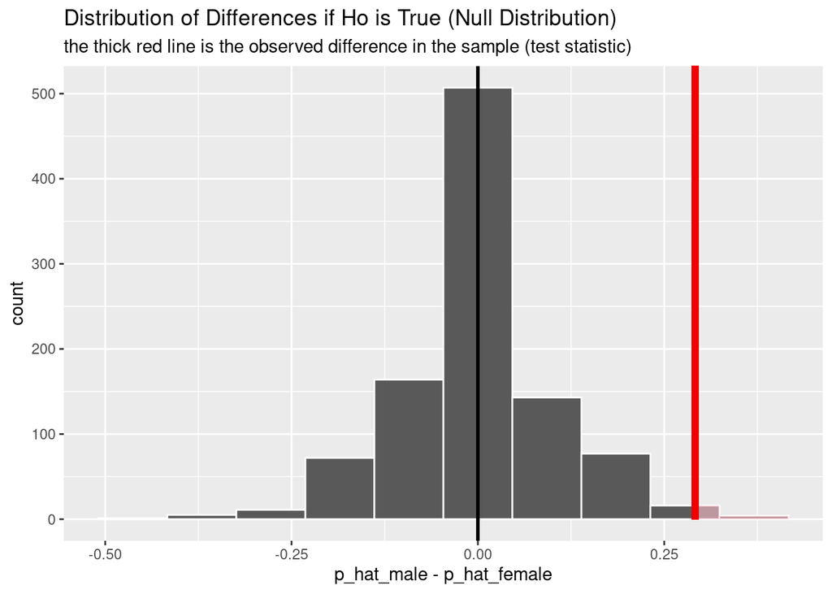

```r
visualize(null_distribution, bins = 10) +
  shade_p_value(obs_stat = obs_diff_prop, direction = "right") +                    # we calculated obs_diff_prop above
  labs(title = "Distribution of Differences if Ho is True (Null Distribution)",
       subtitle = "the thick red line is the observed difference in the sample (test statistic)",
       x = "p_hat_male - p_hat_female") +
  geom_vline(xintercept = 0, size = 1)
```

So what is the probability of getting an observed statistic as large as the one we saw, or even larger?

```r
null_distribution %>%
  get_p_value(obs_stat = obs_diff_prop, direction = "right")
```

```
# A tibble: 1 × 1
  p_value
    <dbl>
1    0.02
```